# “Hb1Ac association analysis”

Zarva I.

## **Общее описание данных:**

#### Датасет содержит 5 доменов с 72 предикторами, включая показатель гликированного гемолгобина (**LBXGH**) в % (далее HbA1c), который будет взят за целевую переменную в регрессионном анализе.Всего наблюдений без пропущенных значений - 916.

## **Выбор предикторов**

#### Для построения статистической модели регрессии использовался набор следующих предикторов:

#### - Среднее артериальное давление (САД) = 1/3 * Сист АД (**BPXSY**) + 2/3 * Диаст АД (**BPXDI**)

###### Связь: люди, страдающие избыточным весом = не имеющие постоянной достаточной физической активности, чаще имеют повышенные показатели АД;

#### - Индекс массы тела - BMI (**BMXBMI**)

###### Связь: 1) У людей с избыточной массой тела, часто развивается инсулинорезистентность, что приводит к увеличению уровня гликированного гемоглобина; 2) Повышенный риск преддиабета и диабета 2 типа -> высокие значения HbA1; 3) У людей с ожирением изменяется липидный и углеводный обмен; 4) У людей с избыточной массой тела часто ниже уровень физической активности, что снижает чувствительность к инсулину и способствует повышению глюкозы в крови, что опять-таки влияет на уровень HbA1c.5) У людей с избыточной массой тела часто наблюдается высококалорийная диета с высоким содержанием простых углеводов.

#### - Для оценки физической активности с учетом предикторов, описывающих величину предложена переменная Activity Days Score (ADS) = (5 * PAQ610) + (3 * PAQ625) + (4 * PAQ640) + (5 * PAQ655) + (3 * PAQ670)

##### Были включены следующие переменные:

##### - PAQ610 - Количество дней интенсивной работы

##### - PAQ625 - Количество дней умеренной работы

##### - PAQ640 - Количество дней ходьбы или езды на велосипеде

##### - PAQ655 - Дни активного отдыха

##### - PAQ670 - Количество дней умеренной рекреационной активности

##### - PAD680 - Минуты сидячей активности

## Анализ распределения целевой переменной

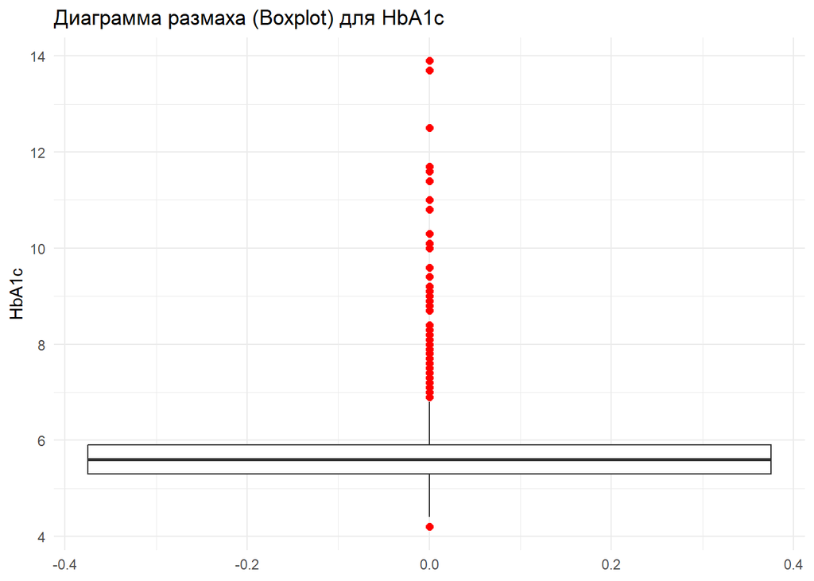

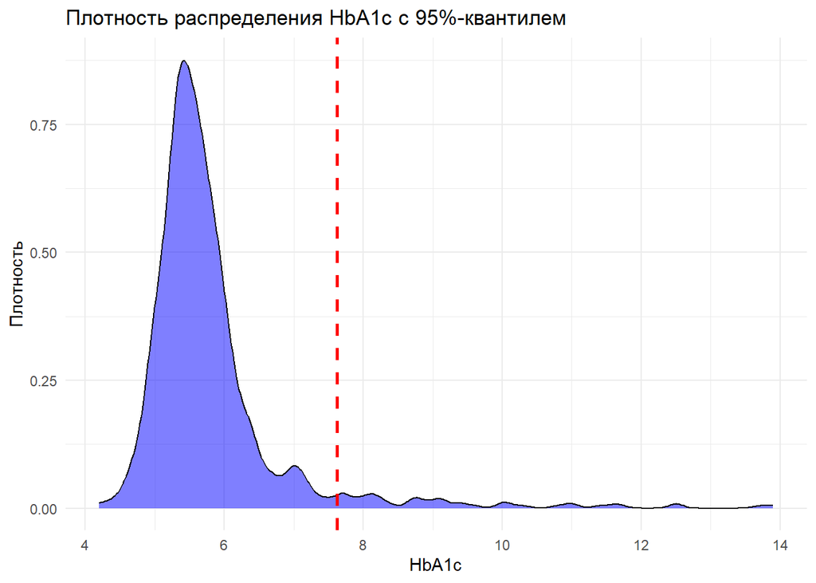

#### Для нивелирования влияния выбросов было принято решение привести их к значению 95 процентиля

```
## [1] "95%-квантиль LBXGH: 7.625"
```

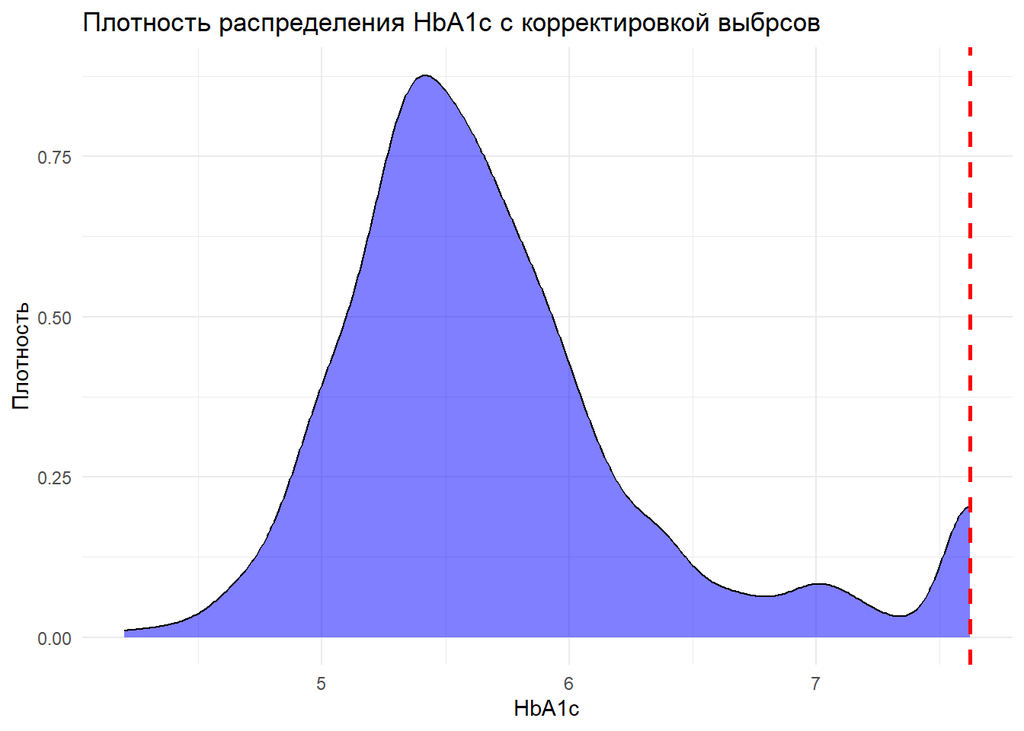

#### Оценка структуры данных

```
## # A tibble: 6 × 16
##   LBXGH1 RIAGENDR BPXSY BPXDI BMXBMI PAQ610 PAQ625 PAQ640 PAQ655 PAQ670 PAD680
##    <dbl> <fct>    <dbl> <dbl>  <dbl>  <dbl>  <dbl>  <dbl>  <dbl>  <dbl>  <dbl>
## 1    6.2 Female    147.  72     27.7      0      0      0      0      7    480
## 2    5.6 Male      114   61.3   24.7      6      3      0      6      0    600
## 3    5.2 Male      115.  70     26.1      5      0      0      0      0    300
## 4    5.8 Male      139.  84.7   30.2      0      5      0      0      0    300
## 5    5.2 Male      141.  76     28.1      0      2      5      0      6    180
## 6    5.3 Male      111.  66     23.5      0      0      0      0      0    420
## # ℹ 5 more variables: DRQSDT7 <fct>, DRQSDT4 <fct>, DIQ070 <fct>, DIQ010 <fct>,
## #   MeanBP <dbl>
```

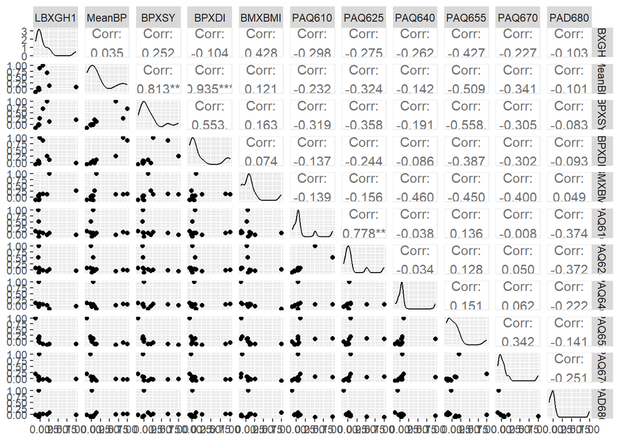

```
## Importance of components:
##                           PC1    PC2    PC3    PC4     PC5     PC6     PC7
## Standard deviation     1.5412 1.2963 1.1617 1.0393 0.99548 0.95404 0.89641
## Proportion of Variance 0.2159 0.1528 0.1227 0.0982 0.09009 0.08274 0.07305
## Cumulative Proportion  0.2159 0.3687 0.4914 0.5896 0.67968 0.76242 0.83547
##                           PC8     PC9    PC10      PC11
## Standard deviation     0.8501 0.78323 0.68819 1.799e-05
## Proportion of Variance 0.0657 0.05577 0.04305 0.000e+00
## Cumulative Proportion  0.9012 0.95695 1.00000 1.000e+00
```

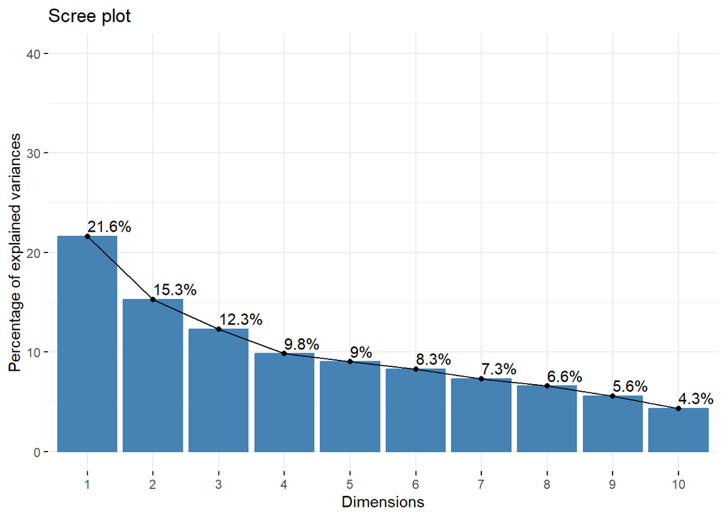

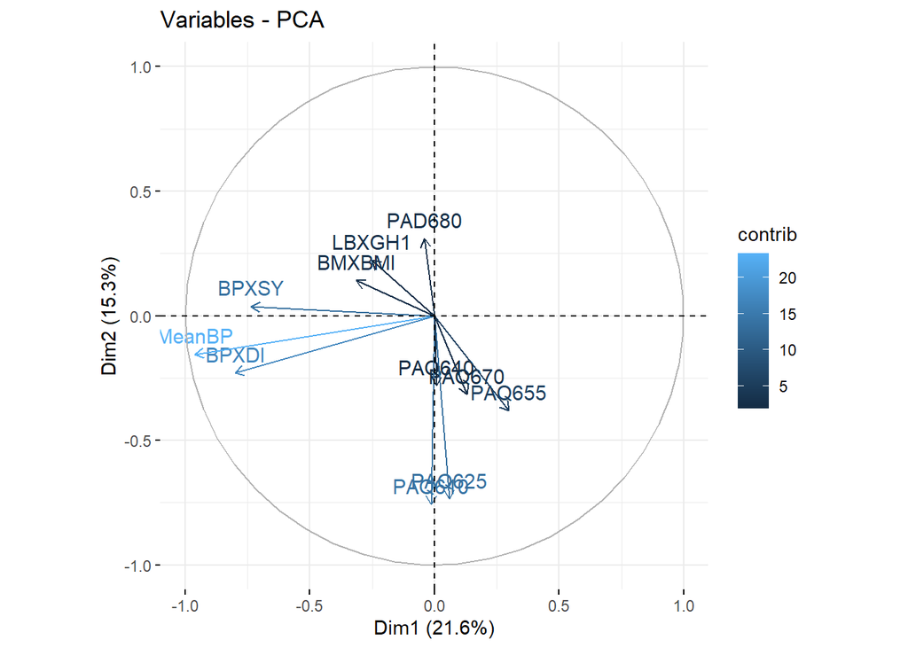

### Наблюдается сильная корреляция некоторых переменных, что может оказать негативный эффект при построении модели.

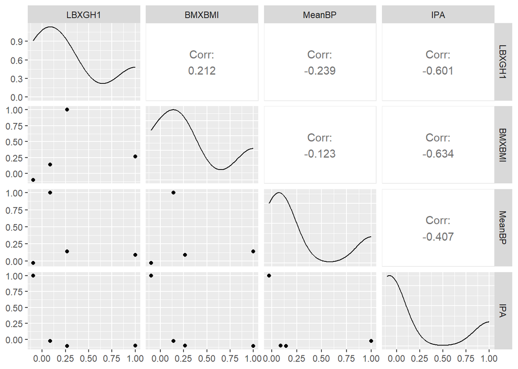

```
## Importance of components:
##                           PC1    PC2    PC3    PC4
## Standard deviation     1.1803 0.9872 0.9516 0.8524
## Proportion of Variance 0.3483 0.2436 0.2264 0.1817
## Cumulative Proportion  0.3483 0.5919 0.8183 1.0000
```

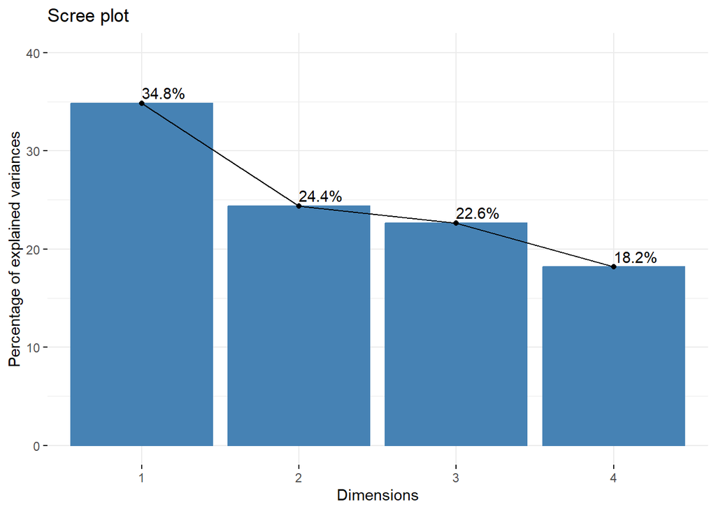

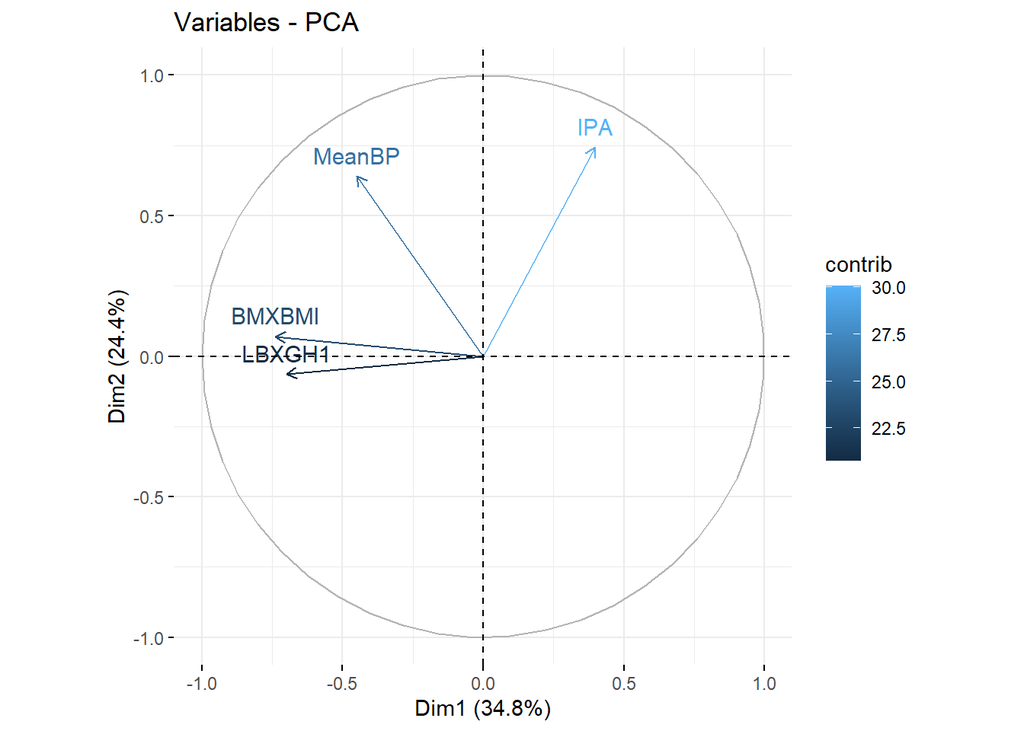

#### Нам необходимо учитывать, что приём гипогликемических препаратов будет модификатором эффекта физической активность на показатель HbA1c. Для исключения данного эффекта, принято исключить из модели пациентов, принимающих такую терапию (**DIQ070**) (уровень наличия корреляции приёма препаратов и уровня HbA1c. R= -0.917);

#### Также наличие заболевания Сахарный диабет I типа вне зависимости от уровня физической активности будет предрасполагать к повышению HbA1c, поэтому на этом этапе исследования пациенты, имеющие диагноз СД (**DIQ010**), не будут включены в модель ;

#### Также необходимо учесть особенности диеты каждого пациента. Пациенты, принимающие диету с низким содержанием/без сахара (**DRQSDT4**) и диабетическую диету (**DRQSDT7**), будут исключены из исследования.

#### Фитирование модели

### Модель 1 (ИМТ, САД, IPA)

```
##
## Call:
## lm(formula = LBXGH1 ~ ., data = df_pred_IPA_model_1)
##
## Residuals:
##      Min       1Q   Median       3Q      Max
## -1.31086 -0.27202 -0.01664  0.24630  2.07757
##
## Coefficients:
##               Estimate Std. Error t value Pr(>|t|)
## (Intercept)  4.9663013  0.1335823  37.178  < 2e-16 ***
## BMXBMI       0.0148861  0.0024802   6.002 3.11e-09 ***
## MeanBP       0.0013694  0.0013584   1.008    0.314
## IPA         -0.0007652  0.0007348  -1.041    0.298
## ---
## Signif. codes:  0 '***' 0.001 '**' 0.01 '*' 0.05 '.' 0.1 ' ' 1
##
## Residual standard error: 0.4114 on 709 degrees of freedom
## Multiple R-squared:  0.05622,    Adjusted R-squared:  0.05222
## F-statistic: 14.08 on 3 and 709 DF,  p-value: 6.378e-09
```

| **Characteristic** | **Beta** | **95% CI**<sup>1</sup> | **p-value** |
| --- | --- | --- | --- |
| BMXBMI | 0.01 | 0.01, 0.02 | <0.001 |
| MeanBP | 0.00 | 0.00, 0.00 | 0.3 |
| IPA | 0.00 | 0.00, 0.00 | 0.3 |

<sup>1</sup> CI = Confidence Interval

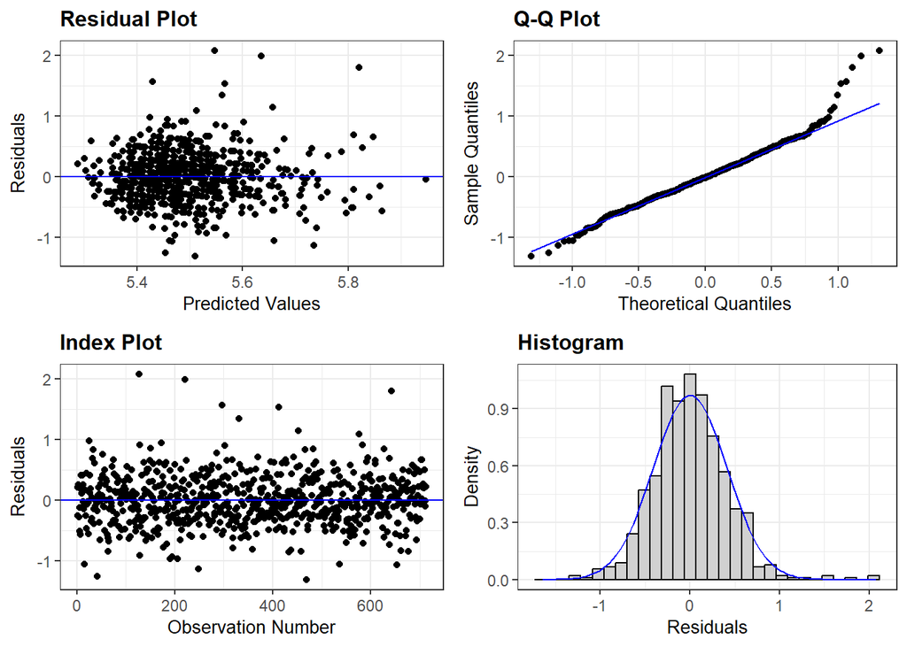

```
##   BMXBMI   MeanBP      IPA
## 1.028911 1.023540 1.008729
```

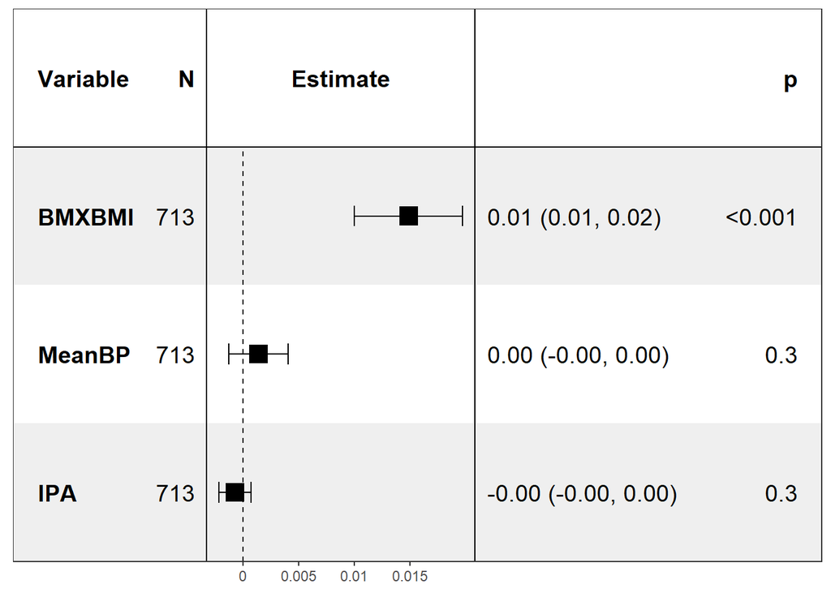

### Модель 2 (САД, IPA)

```
##
## Call:
## lm(formula = LBXGH1 ~ ., data = df_pred_IPA_model_2)
##
## Residuals:
##      Min       1Q   Median       3Q      Max
## -1.33889 -0.27257 -0.01478  0.24946  2.14088
##
## Coefficients:
##               Estimate Std. Error t value Pr(>|t|)
## (Intercept)  5.2957007  0.1247553  42.449   <2e-16 ***
## MeanBP       0.0025457  0.0013769   1.849   0.0649 .
## IPA         -0.0011191  0.0007503  -1.492   0.1362
## ---
## Signif. codes:  0 '***' 0.001 '**' 0.01 '*' 0.05 '.' 0.1 ' ' 1
##
## Residual standard error: 0.4214 on 710 degrees of freedom
## Multiple R-squared:  0.008264,   Adjusted R-squared:  0.005471
## F-statistic: 2.958 on 2 and 710 DF,  p-value: 0.05255
```

| **Characteristic** | **Beta** | **95% CI**<sup>1</sup> | **p-value** |
| --- | --- | --- | --- |
| MeanBP | 0.00 | 0.00, 0.01 | 0.065 |
| IPA | 0.00 | 0.00, 0.00 | 0.14 |

<sup>1</sup> CI = Confidence Interval

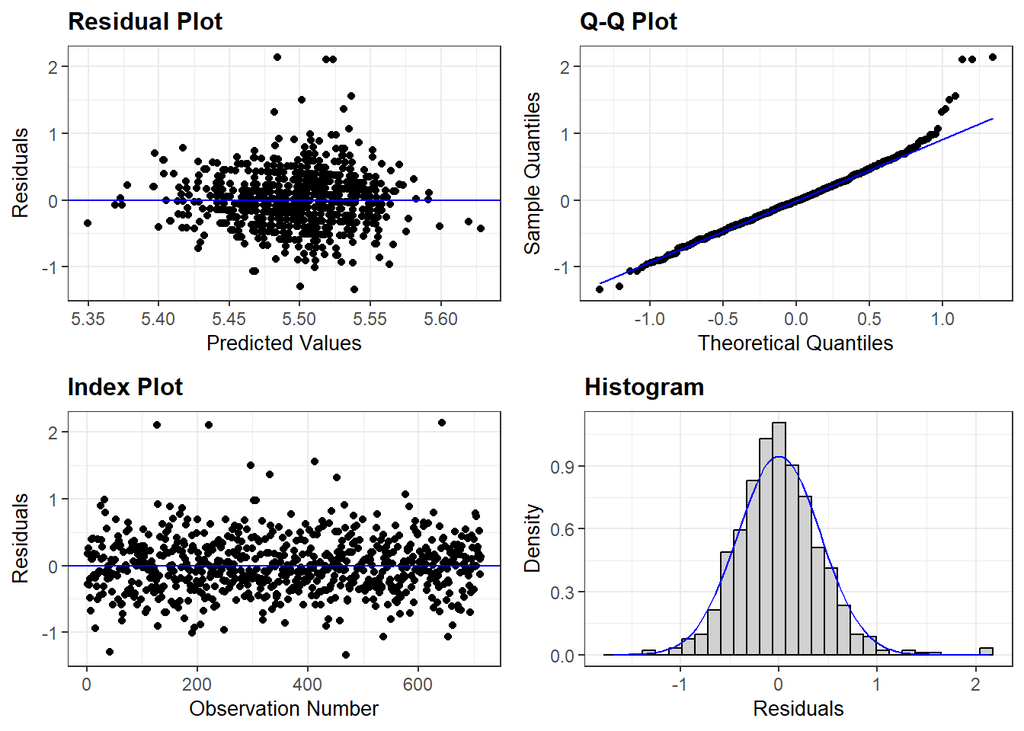

```
##   MeanBP      IPA
## 1.002234 1.002234
```

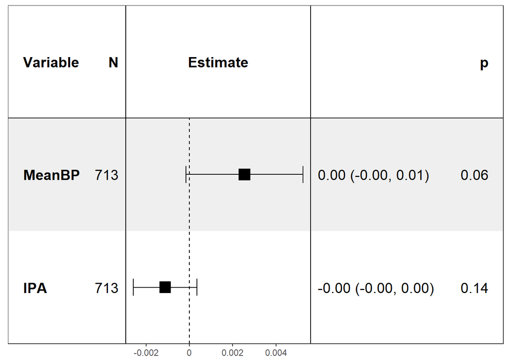

### Модель 3 (IPA, ИМТ)

```
##
## Call:
## lm(formula = LBXGH1 ~ ., data = df_pred_IPA_model_3)
##
## Residuals:
##     Min      1Q  Median      3Q     Max
## -1.2956 -0.2657 -0.0236  0.2409  2.0776
##
## Coefficients:
##               Estimate Std. Error t value Pr(>|t|)
## (Intercept)  5.0778236  0.0748770  67.816  < 2e-16 ***
## BMXBMI       0.0152468  0.0024543   6.212 8.89e-10 ***
## IPA         -0.0007912  0.0007343  -1.077    0.282
## ---
## Signif. codes:  0 '***' 0.001 '**' 0.01 '*' 0.05 '.' 0.1 ' ' 1
##
## Residual standard error: 0.4114 on 710 degrees of freedom
## Multiple R-squared:  0.05486,    Adjusted R-squared:  0.0522
## F-statistic: 20.61 on 2 and 710 DF,  p-value: 1.997e-09
```

| **Characteristic** | **Beta** | **95% CI**<sup>1</sup> | **p-value** |
| --- | --- | --- | --- |
| BMXBMI | 0.02 | 0.01, 0.02 | <0.001 |
| IPA | 0.00 | 0.00, 0.00 | 0.3 |

<sup>1</sup> CI = Confidence Interval

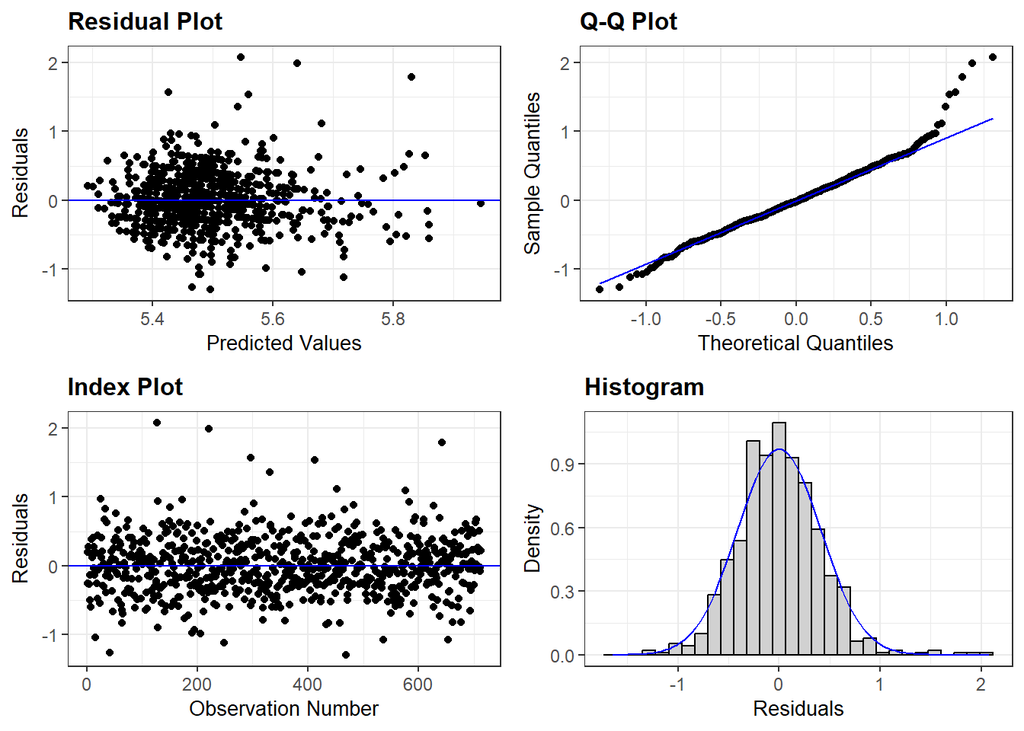

```
##   BMXBMI      IPA
## 1.007493 1.007493
```

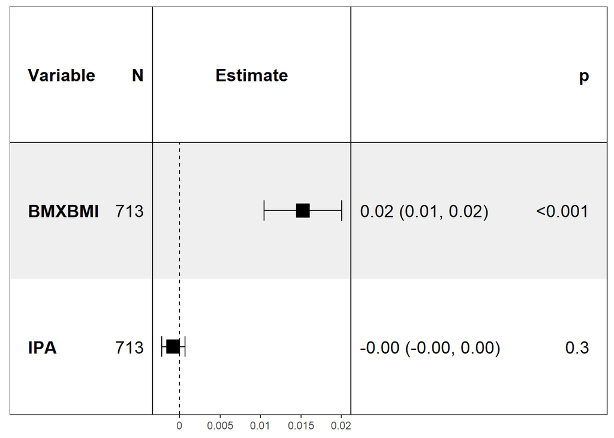

### Модель 4 (IPA)

```
##
## Call:
## lm(formula = LBXGH1 ~ ., data = df_pred_IPA_model_4)
##
## Residuals:
##      Min       1Q   Median       3Q      Max
## -1.32258 -0.27327 -0.01942  0.25531  2.13771
##
## Coefficients:
##               Estimate Std. Error t value Pr(>|t|)
## (Intercept)  5.5225791  0.0225072 245.369   <2e-16 ***
## IPA         -0.0011846  0.0007507  -1.578    0.115
## ---
## Signif. codes:  0 '***' 0.001 '**' 0.01 '*' 0.05 '.' 0.1 ' ' 1
##
## Residual standard error: 0.4222 on 711 degrees of freedom
## Multiple R-squared:  0.00349,    Adjusted R-squared:  0.002088
## F-statistic:  2.49 on 1 and 711 DF,  p-value: 0.115
```

| **Characteristic** | **Beta** | **95% CI**<sup>1</sup> | **p-value** |
| --- | --- | --- | --- |
| IPA | 0.00 | 0.00, 0.00 | 0.12 |

<sup>1</sup> CI = Confidence Interval

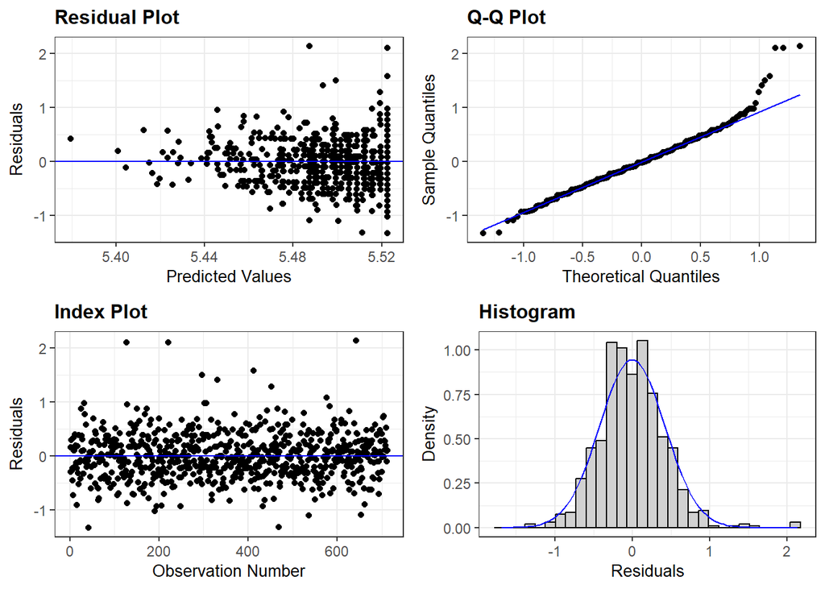

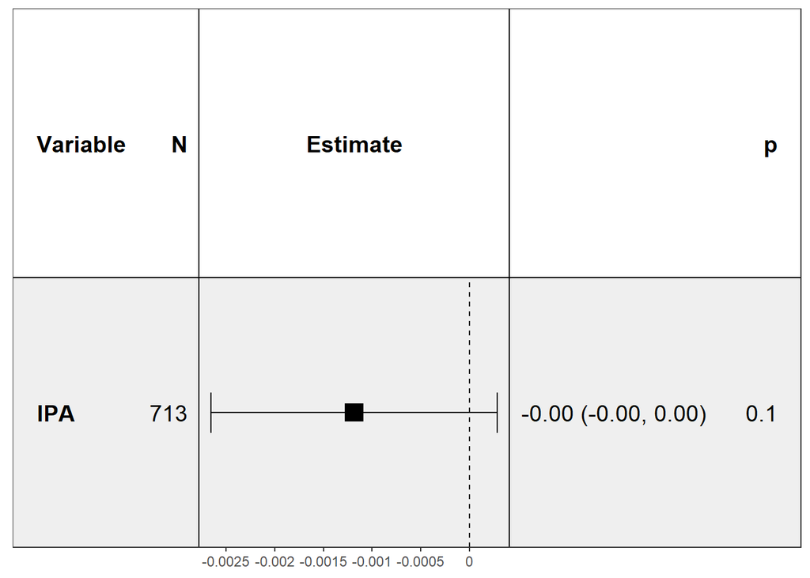

### Модель 5 (ИМТ, САД)

```
##
## Call:
## lm(formula = LBXGH1 ~ ., data = df_pred_model_5)
##
## Residuals:
##      Min       1Q   Median       3Q      Max
## -1.30234 -0.26978 -0.01452  0.23372  2.09340
##
## Coefficients:
##             Estimate Std. Error t value Pr(>|t|)
## (Intercept) 4.939655   0.131117  37.674  < 2e-16 ***
## BMXBMI      0.015093   0.002472   6.105 1.69e-09 ***
## MeanBP      0.001419   0.001358   1.045    0.296
## ---
## Signif. codes:  0 '***' 0.001 '**' 0.01 '*' 0.05 '.' 0.1 ' ' 1
##
## Residual standard error: 0.4114 on 710 degrees of freedom
## Multiple R-squared:  0.05477,    Adjusted R-squared:  0.05211
## F-statistic: 20.57 on 2 and 710 DF,  p-value: 2.066e-09
```

| **Characteristic** | **Beta** | **95% CI**<sup>1</sup> | **p-value** |
| --- | --- | --- | --- |
| BMXBMI | 0.02 | 0.01, 0.02 | <0.001 |
| MeanBP | 0.00 | 0.00, 0.00 | 0.3 |

<sup>1</sup> CI = Confidence Interval

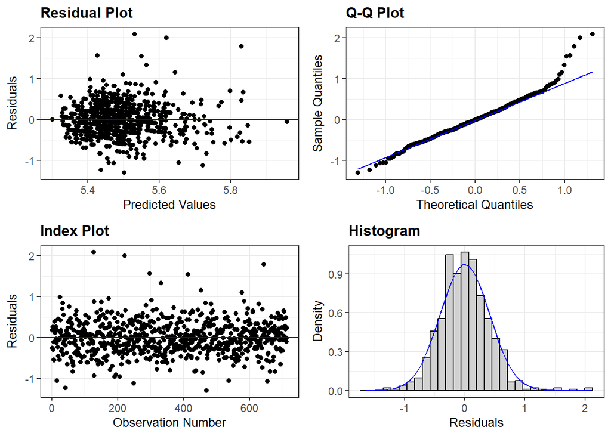

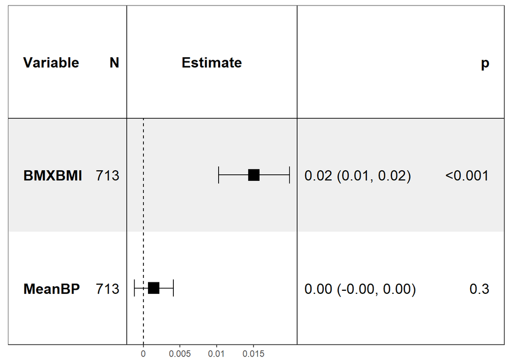

### Модель 6 (ИМТ)

```
##
## Call:
## lm(formula = LBXGH1 ~ ., data = df_pred_IPA_model_6)
##
## Residuals:
##      Min       1Q   Median       3Q      Max
## -1.28616 -0.26663 -0.02175  0.24015  2.09396
##
## Coefficients:
##             Estimate Std. Error t value Pr(>|t|)
## (Intercept) 5.054414   0.071663  70.530  < 2e-16 ***
## BMXBMI      0.015475   0.002445   6.328 4.39e-10 ***
## ---
## Signif. codes:  0 '***' 0.001 '**' 0.01 '*' 0.05 '.' 0.1 ' ' 1
##
## Residual standard error: 0.4115 on 711 degrees of freedom
## Multiple R-squared:  0.05332,    Adjusted R-squared:  0.05199
## F-statistic: 40.05 on 1 and 711 DF,  p-value: 4.391e-10
```

| **Characteristic** | **Beta** | **95% CI**<sup>1</sup> | **p-value** |
| --- | --- | --- | --- |
| BMXBMI | 0.02 | 0.01, 0.02 | <0.001 |

<sup>1</sup> CI = Confidence Interval

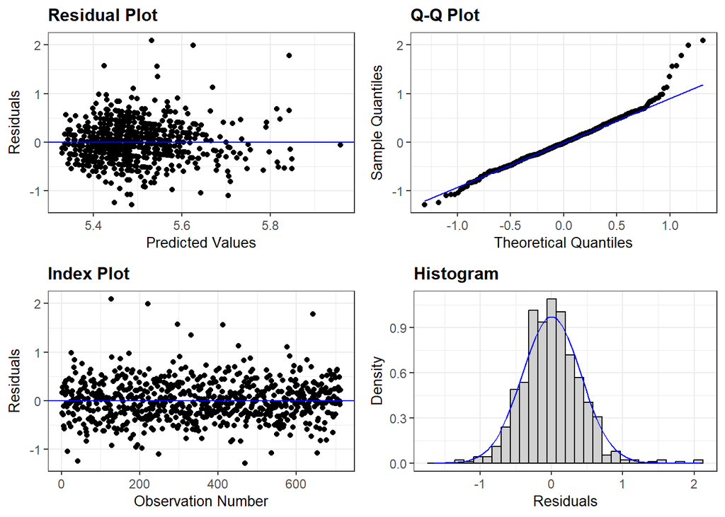

```
## Resized limits to included dashed line in forest panel
```

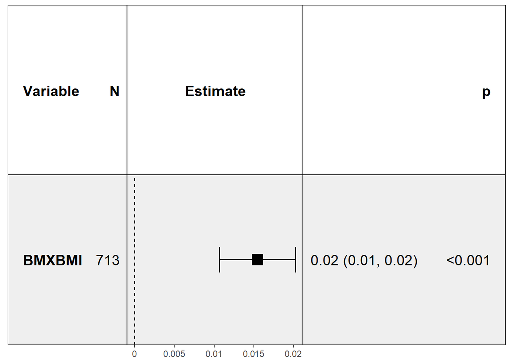

### Были сравнены регрессионные модели, использующих разные комбинации предикторов: Модель 1 (ИМТ, САД, IPA), Модель 2 (САД, IPA), Модель 3 (IPA, ИМТ), Модель 4 (IPA), Модель 5 (ИМТ, САД), Модель 6 (ИМТ). Большое влияние на уровень гликированного гемоглобина оказывает ИМТ. Расчитанный индекс активности (IPA) хоть и имеет значительную обратную корреляцию с HbA1c сильный вклад в регрессию не внёс. Однако, лучший результат по метрике R^2 = 0.05622 показала модель, использующая все 3 переменные.